## **The Global Terrorism Database (GTD) is an open-source database including information on terrorist attacks around the world from 1970 through 2017. The GTD includes systematic data on domestic as well as international terrorist incidents that have occurred during this time period and now includes more than 180,000 attacks. The database is maintained by researchers at the National Consortium for the Study of Terrorism and Responses to Terrorism (START), headquartered at the University of Maryland.**

# **Explore and analyze the data to discover key findings pertaining to terrorist activities.**

# Author:-Rushikesh Pandhare

```python
import pandas as pd
import numpy as np
import seaborn as sns
import matplotlib.pyplot as plt
```

```python
#import the Gobal Terrorism dataset
data = pd.read_csv("D:\All Data\globalterrorism.csv",encoding="latin-1")
```

```python
#show all columns in the dataset
pd.set_option('display.max_columns',None)
```

```python
data.head(5)
```

|  | eventid | iyear | imonth | iday | approxdate | extended | resolution | country | country_txt | region | region_txt | provstate | city | latitude | longitude | specificity | vicinity | location | summary | crit1 | crit2 | crit3 | doubtterr | alternative | alternative_txt | multiple | success | suicide | attacktype1 | … |
| --- | --- | --- | --- | --- | --- | --- | --- | --- | --- | --- | --- | --- | --- | --- | --- | --- | --- | --- | --- | --- | --- | --- | --- | --- | --- | --- | --- | --- | --- | --- |
| 0 | 1.970000e+11 | 1970 | 7 | 2 | NaN | 0 | NaN | 58 | Dominican Republic | 2 | Central America & Caribbean | NaN | Santo Domingo | 18.456792 | -69.951164 | 1.0 | 0 | NaN | NaN | 1 | 1 | 1 | 0.0 | NaN | NaN | 0.0 | 1 | 0 | 1 | … |
| 1 | 1.970000e+11 | 1970 | 0 | 0 | NaN | 0 | NaN | 130 | Mexico | 1 | North America | Federal | Mexico city | 19.371887 | -99.086624 | 1.0 | 0 | NaN | NaN | 1 | 1 | 1 | 0.0 | NaN | NaN | 0.0 | 1 | 0 | 6 | … |
| 2 | 1.970010e+11 | 1970 | 1 | 0 | NaN | 0 | NaN | 160 | Philippines | 5 | Southeast Asia | Tarlac | Unknown | 15.478598 | 120.599741 | 4.0 | 0 | NaN | NaN | 1 | 1 | 1 | 0.0 | NaN | NaN | 0.0 | 1 | 0 | 1 | … |
| 3 | 1.970010e+11 | 1970 | 1 | 0 | NaN | 0 | NaN | 78 | Greece | 8 | Western Europe | Attica | Athens | 37.997490 | 23.762728 | 1.0 | 0 | NaN | NaN | 1 | 1 | 1 | 0.0 | NaN | NaN | 0.0 | 1 | 0 | 3 | … |
| 4 | 1.970010e+11 | 1970 | 1 | 0 | NaN | 0 | NaN | 101 | Japan | 4 | East Asia | Fukouka | Fukouka | 33.580412 | 130.396361 | 1.0 | 0 | NaN | NaN | 1 | 1 | 1 | -9.0 | NaN | NaN | 0.0 | 1 | 0 | 7 | … |

```python
#number of rows and columns present in dataset
data.shape
```

```
(181691, 135)
```

```python
pd.set_option('display.max_rows',None)
```

```python
#Attribute infromation
data.info()
```

```
<class 'pandas.core.frame.DataFrame'>
RangeIndex: 181691 entries, 0 to 181690
Columns: 135 entries, eventid to related
dtypes: float64(56), int64(21), object(58)
memory usage: 187.1+ MB
```

```python
#data types
data.dtypes
```

```
eventid               float64
iyear                   int64
imonth                  int64
iday                    int64
approxdate             object
extended                int64
resolution             object
country                 int64
country_txt            object
region                  int64
region_txt             object
provstate              object
city                   object
latitude              float64
longitude             float64
specificity           float64
vicinity                int64
location               object
summary                object
crit1                   int64
crit2                   int64
crit3                   int64
doubtterr             float64
alternative           float64
alternative_txt        object
multiple              float64
success                 int64
suicide                 int64
attacktype1             int64
attacktype1_txt        object
attacktype2           float64
attacktype2_txt        object
attacktype3           float64
attacktype3_txt        object
targtype1               int64
targtype1_txt          object
targsubtype1          float64
targsubtype1_txt       object
corp1                  object
target1                object
```

[output cut: 81 more lines]

```
ransomnote             object
hostkidoutcome        float64
hostkidoutcome_txt     object
nreleased             float64
addnotes               object
scite1                 object
scite2                 object
scite3                 object
dbsource               object
INT_LOG                 int64
INT_IDEO                int64
INT_MISC                int64
INT_ANY                 int64
related                object
dtype: object
```

```python
#null values and its count
data.isna().sum()
```

```
eventid                    0
iyear                      0
imonth                     0
iday                       0
approxdate            172452
extended                   0
resolution            179471
country                    0
country_txt                0
region                     0
region_txt                 0
provstate                421
city                     434
latitude                4556
longitude               4557
specificity                6
vicinity                   0
location              126196
summary                66129
crit1                      0
crit2                      0
crit3                      0
doubtterr                  1
alternative           152680
alternative_txt       152680
multiple                   1
success                    0
suicide                    0
attacktype1                0
attacktype1_txt            0
attacktype2           175377
attacktype2_txt       175377
attacktype3           181263
attacktype3_txt       181263
targtype1                  0
targtype1_txt              0
targsubtype1           10373
targsubtype1_txt       10373
corp1                  42550
target1                  636
```

[output cut: 81 more lines]

```
ransomnote            181177
hostkidoutcome        170700
hostkidoutcome_txt    170700
nreleased             171291
addnotes              153402
scite1                 66191
scite2                104758
scite3                138175
dbsource                   0
INT_LOG                    0
INT_IDEO                   0
INT_MISC                   0
INT_ANY                    0
related               156653
dtype: int64
```

```python
#percentage of Null values
data.isna().sum()*100/len(data)
```

```
eventid                0.000000
iyear                  0.000000
imonth                 0.000000
iday                   0.000000
approxdate            94.914993
extended               0.000000
resolution            98.778145
country                0.000000
country_txt            0.000000
region                 0.000000
region_txt             0.000000
provstate              0.231712
city                   0.238867
latitude               2.507554
longitude              2.508104
specificity            0.003302
vicinity               0.000000
location              69.456385
summary               36.396409
crit1                  0.000000
crit2                  0.000000
crit3                  0.000000
doubtterr              0.000550
alternative           84.032781
alternative_txt       84.032781
multiple               0.000550
success                0.000000
suicide                0.000000
attacktype1            0.000000
attacktype1_txt        0.000000
attacktype2           96.524869
attacktype2_txt       96.524869
attacktype3           99.764435
attacktype3_txt       99.764435
targtype1              0.000000
targtype1_txt          0.000000
targsubtype1           5.709144
targsubtype1_txt       5.709144
corp1                 23.418882
target1                0.350045
```

[output cut: 81 more lines]

```
ransomnote            99.717102
hostkidoutcome        93.950719
hostkidoutcome_txt    93.950719
nreleased             94.275996
addnotes              84.430159
scite1                36.430533
scite2                57.657231
scite3                76.049447
dbsource               0.000000
INT_LOG                0.000000
INT_IDEO               0.000000
INT_MISC               0.000000
INT_ANY                0.000000
related               86.219461
dtype: float64
```

```python
#the columns heading not make any sense,so we will rename it for better understanding.
data.rename(columns={'iyear':'Year','imonth':'Month','iday':'Day','country_txt':'Country','provstate':'State','region_txt':'Region','attacktype1_txt':'AttackType','target1':'Target','success':'Success','nkill':'Killed','nwound':'Wounded','summary':'Summary','gname':'Group','targtype1_txt':'Target_type','weaptype1_txt':'Weapon_type','motive':'Motive'},inplace=True)
```

```python
#dataset columns
list(data.columns)
```

```
['eventid',
 'Year',
 'Month',
 'Day',
 'approxdate',
 'extended',
 'resolution',
 'country',
 'Country',
 'region',
 'Region',
 'State',
 'city',
 'latitude',
 'longitude',
 'specificity',
 'vicinity',
 'location',
 'Summary',
 'crit1',
 'crit2',
 'crit3',
 'doubtterr',
 'alternative',
 'alternative_txt',
 'multiple',
 'Success',
 'suicide',
 'attacktype1',
 'AttackType',
 'attacktype2',
 'attacktype2_txt',
 'attacktype3',
 'attacktype3_txt',
 'targtype1',
 'Target_type',
 'targsubtype1',
 'targsubtype1_txt',
 'corp1',
 'Target',
```

[output cut: 80 more lines]

```
 'ransompaidus',
 'ransomnote',
 'hostkidoutcome',
 'hostkidoutcome_txt',
 'nreleased',
 'addnotes',
 'scite1',
 'scite2',
 'scite3',
 'dbsource',
 'INT_LOG',
 'INT_IDEO',
 'INT_MISC',
 'INT_ANY',
 'related']
```

```python
'''
Global Terrorism dataset having 135 columns and some of columns have most 99% null values,
thats not contribute in the analysis so we removed the null values and keep only neccessary columns from the dataset.
'''
columns_to_keep = ['Year','Month','Day','Country','State','Region','latitude','longitude','AttackType','Success','Target','Killed','Wounded','Summary','Group','Target_type',
                   'Weapon_type','Motive']

data = data[columns_to_keep]
```

```python
#new extracted dataset
data.head()
```

|  | Year | Month | Day | Country | State | Region | latitude | longitude | AttackType | Success | Target | Killed | Wounded | Summary | Group | Target_type | Weapon_type | Motive |
| --- | --- | --- | --- | --- | --- | --- | --- | --- | --- | --- | --- | --- | --- | --- | --- | --- | --- | --- |
| 0 | 1970 | 7 | 2 | Dominican Republic | NaN | Central America & Caribbean | 18.456792 | -69.951164 | Assassination | 1 | Julio Guzman | 1.0 | 0.0 | NaN | MANO-D | Private Citizens & Property | Unknown | NaN |
| 1 | 1970 | 0 | 0 | Mexico | Federal | North America | 19.371887 | -99.086624 | Hostage Taking (Kidnapping) | 1 | Nadine Chaval, daughter | 0.0 | 0.0 | NaN | 23rd of September Communist League | Government (Diplomatic) | Unknown | NaN |
| 2 | 1970 | 1 | 0 | Philippines | Tarlac | Southeast Asia | 15.478598 | 120.599741 | Assassination | 1 | Employee | 1.0 | 0.0 | NaN | Unknown | Journalists & Media | Unknown | NaN |
| 3 | 1970 | 1 | 0 | Greece | Attica | Western Europe | 37.997490 | 23.762728 | Bombing/Explosion | 1 | U.S. Embassy | NaN | NaN | NaN | Unknown | Government (Diplomatic) | Explosives | NaN |
| 4 | 1970 | 1 | 0 | Japan | Fukouka | East Asia | 33.580412 | 130.396361 | Facility/Infrastructure Attack | 1 | U.S. Consulate | NaN | NaN | NaN | Unknown | Government (Diplomatic) | Incendiary | NaN |

```python
#Size of new dataset
data.shape
```

```
(181691, 18)
```

```python
#Remove eventid
#data=data.drop('eventid', axis=1, inplace=False)
```

```python
#details about dataset
data.describe()
```

|  | Year | Month | Day | latitude | longitude | Success | Killed | Wounded |
| --- | --- | --- | --- | --- | --- | --- | --- | --- |
| count | 181691.000000 | 181691.000000 | 181691.000000 | 177135.000000 | 1.771340e+05 | 181691.000000 | 171378.000000 | 165380.000000 |
| mean | 2002.638997 | 6.467277 | 15.505644 | 23.498343 | -4.586957e+02 | 0.889598 | 2.403272 | 3.167668 |
| std | 13.259430 | 3.388303 | 8.814045 | 18.569242 | 2.047790e+05 | 0.313391 | 11.545741 | 35.949392 |
| min | 1970.000000 | 0.000000 | 0.000000 | -53.154613 | -8.618590e+07 | 0.000000 | 0.000000 | 0.000000 |
| 25% | 1991.000000 | 4.000000 | 8.000000 | 11.510046 | 4.545640e+00 | 1.000000 | 0.000000 | 0.000000 |
| 50% | 2009.000000 | 6.000000 | 15.000000 | 31.467463 | 4.324651e+01 | 1.000000 | 0.000000 | 0.000000 |
| 75% | 2014.000000 | 9.000000 | 23.000000 | 34.685087 | 6.871033e+01 | 1.000000 | 2.000000 | 2.000000 |
| max | 2017.000000 | 12.000000 | 31.000000 | 74.633553 | 1.793667e+02 | 1.000000 | 1570.000000 | 8191.000000 |

```python
#correlation
data.corr()
```

|  | Year | Month | Day | latitude | longitude | Success | Killed | Wounded |
| --- | --- | --- | --- | --- | --- | --- | --- | --- |
| Year | 1.000000 | 0.000139 | 0.018254 | 0.166933 | 0.003917 | -0.082963 | 0.015341 | 0.015273 |
| Month | 0.000139 | 1.000000 | 0.005497 | -0.015978 | -0.003880 | -0.002845 | 0.003463 | 0.002938 |
| Day | 0.018254 | 0.005497 | 1.000000 | 0.003423 | -0.002285 | -0.011802 | -0.003693 | -0.001268 |
| latitude | 0.166933 | -0.015978 | 0.003423 | 1.000000 | 0.001463 | -0.073715 | -0.018124 | 0.015988 |
| longitude | 0.003917 | -0.003880 | -0.002285 | 0.001463 | 1.000000 | -0.000858 | -0.000562 | 0.000223 |
| Success | -0.082963 | -0.002845 | -0.011802 | -0.073715 | -0.000858 | 1.000000 | 0.053115 | 0.025804 |
| Killed | 0.015341 | 0.003463 | -0.003693 | -0.018124 | -0.000562 | 0.053115 | 1.000000 | 0.534375 |
| Wounded | 0.015273 | 0.002938 | -0.001268 | 0.015988 | 0.000223 | 0.025804 | 0.534375 | 1.000000 |

```
(array([0.5, 1.5, 2.5, 3.5, 4.5, 5.5, 6.5, 7.5]),
 [Text(0, 0.5, 'Year'),
```

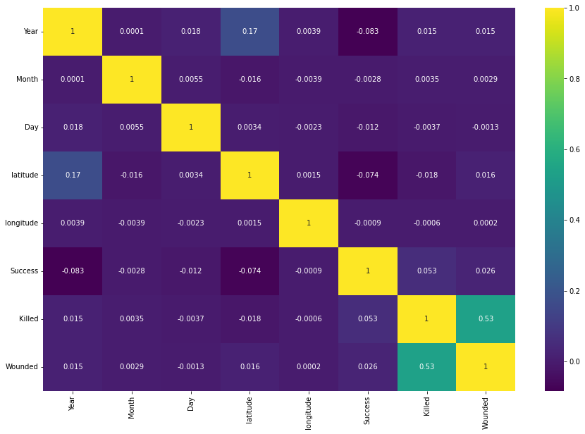

```python
#Correlation Analysis
plt.figure(figsize=(15,10))

sns.heatmap(np.round(data.corr(),4), annot=True, cmap = 'viridis')
plt.xticks(rotation = 90)
plt.yticks(rotation = 0)
```

# **Data Visualization**

**1.Terrorist Activities in Each Year**

```
(array([ 0,  1,  2,  3,  4,  5,  6,  7,  8,  9, 10, 11, 12, 13, 14, 15, 16,
        17, 18, 19, 20, 21, 22, 23, 24, 25, 26, 27, 28, 29, 30, 31, 32, 33,
        34, 35, 36, 37, 38, 39, 40, 41, 42, 43, 44, 45, 46]),
 [Text(0, 0, '1970'),
```

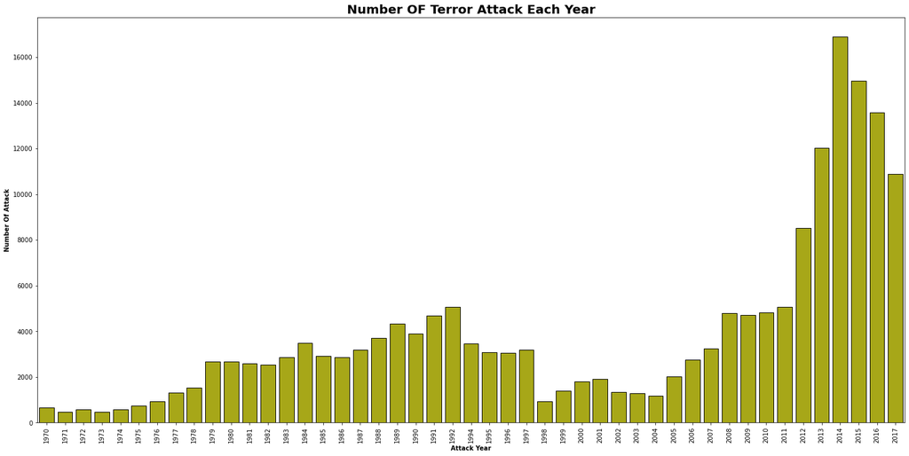

```python
plt.figure(figsize=(25,12))
sns.countplot(data['Year'], color='y', edgecolor='k')
plt.xlabel('Attack Year',fontweight='bold')
plt.ylabel('Number Of Attack',fontweight='bold')
plt.title('Number OF Terror Attack Each Year', fontweight='bold',fontsize=20)
plt.xticks(rotation = 90)
```

## **In Year 2014 and 2015 has a larger Number of Terrorist Activities**

**2.Number of Success Attacks Each Year**

[figure not shown]

```python
plt.figure(figsize=(25,12))
sns.countplot(x=data['Year'], hue='Success', data=data, edgecolor = 'k')
plt.xlabel('Attack Year',fontweight='bold')
plt.ylabel('Number Of Attack',fontweight='bold')
plt.title('Number OF Terror Attack Each Year', fontweight='bold',fontsize=20)
plt.xticks(rotation = 90)
plt.legend(title='Attacks', loc='upper left', labels=['Success Attack', 'Unsuccess Attack'], fontsize=12)
```

**3.Terrorist Activities by Region In Each Year**

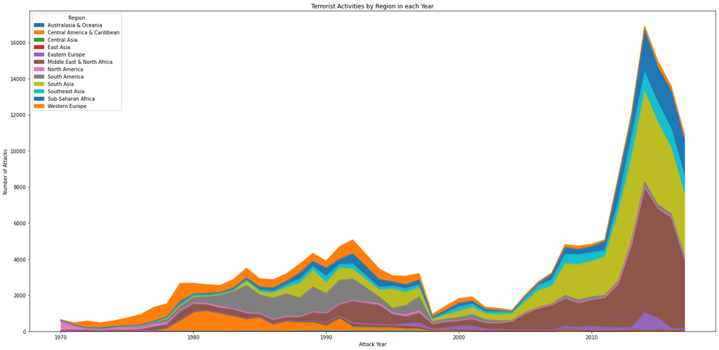

```python
pd.crosstab(data['Year'], data['Region']).plot(kind='area', figsize=(25,12))
plt.title('Terrorist Activities by Region in each Year')
plt.xlabel('Attack Year')
plt.ylabel('Number of Attacks')
plt.show()
```

## **In 'Middle East & North Africa' Region having Most attacks.**

**4.Type of Attack**

```
(array([0, 1, 2, 3, 4, 5, 6, 7, 8]),
 [Text(0, 0, 'Bombing/Explosion'),
```

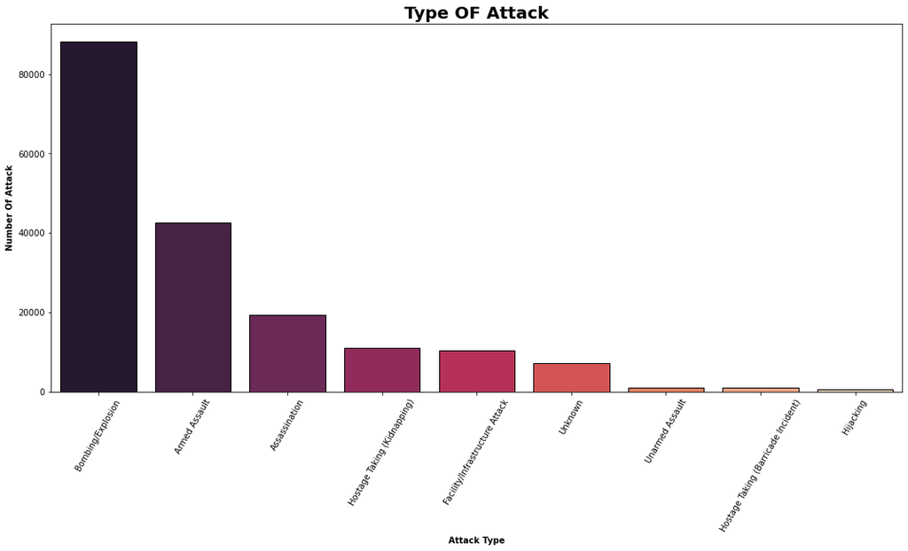

```python
plt.figure(figsize=(18,8))
sns.countplot(data['AttackType'], order=data['AttackType'].value_counts().index, edgecolor='k',palette='rocket')
plt.xlabel('Attack Type',fontweight='bold')
plt.ylabel('Number Of Attack',fontweight='bold')
plt.title('Type OF Attack', fontweight='bold',fontsize=20)
plt.xticks(rotation = 60)
```

## **Maximum Number Of Attack are From Bombing/Explosion and Armed Assault**

**5.Type of Target**

```
(array([ 0,  1,  2,  3,  4,  5,  6,  7,  8,  9, 10, 11, 12, 13, 14, 15, 16,
        17, 18, 19, 20, 21]),
 [Text(0, 0, 'Private Citizens & Property'),
```

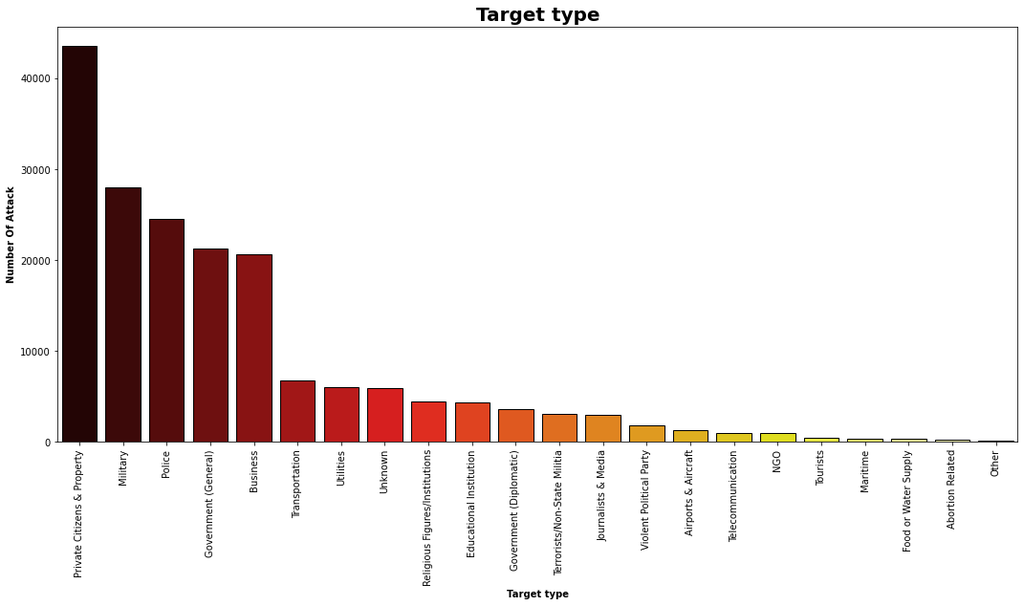

```python
plt.figure(figsize=(18,8))
sns.countplot(data['Target_type'], order=data['Target_type'].value_counts().index, edgecolor='k',palette='hot')
plt.xlabel('Target type',fontweight='bold')
plt.ylabel('Number Of Attack',fontweight='bold')
plt.title('Target type', fontweight='bold',fontsize=20)
plt.xticks(rotation = 90)
```

## **The Main Target of Terrorist is Private Citizens&Property and Military.**

**6.Most Active Terrorrist Groups**

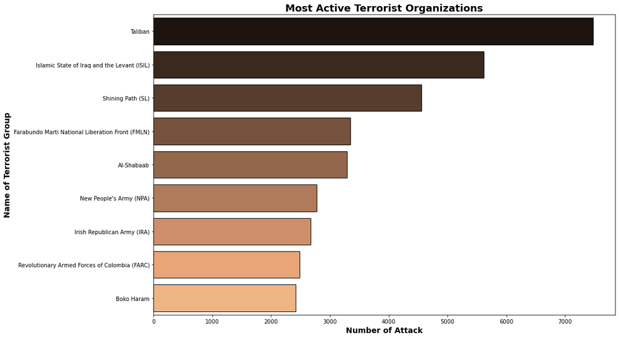

```python
plt.figure(figsize=(15,10))
sns.barplot(y=data['Group'].value_counts()[1:10].index,x=data['Group'].value_counts()[1:10].values,
           palette='copper',edgecolor='k')
plt.xlabel('Number of Attack',fontweight='bold',fontsize=14)
plt.ylabel('Name of Terrorist Group', fontweight='bold',fontsize=14)
plt.title('Most Active Terrorist Organizations', fontweight='bold',fontsize=18)
plt.show()
```

## **Taliban and ISIL are Most Active Terrorist Organisation**

**7.Total Number of Attack in Each Contry and Region**(Top10)

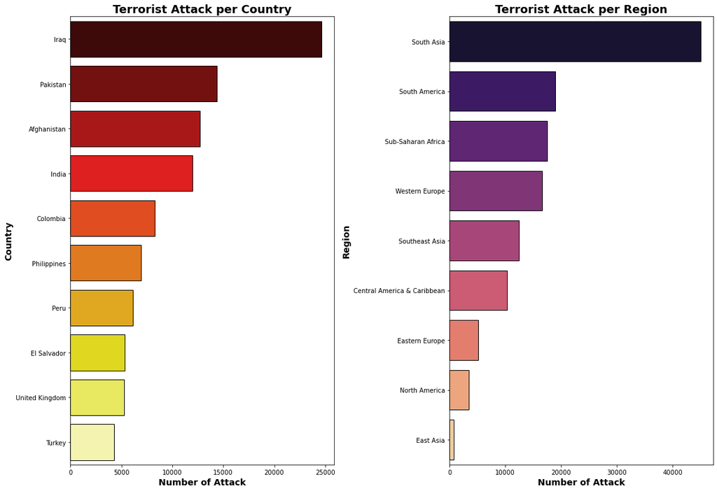

```python
#plt.figure(figsize=(15,10))
#axes=plt.subplots(nrows=1, ncols=2)
fig,axes = plt.subplots(figsize=(16,11),nrows=1,ncols=2)
sns.barplot(y=data['Country'].value_counts()[0:10].index,x=data['Country'].value_counts()[0:10].values,palette='hot', ax=axes[0],edgecolor='k' )
axes[0].set_title('Terrorist Attack per Country',fontweight='bold',fontsize=18)
axes[0].set_xlabel('Number of Attack',fontweight='bold',fontsize=14)
axes[0].set_ylabel('Country', fontweight='bold',fontsize=14)


sns.barplot(y=data['Region'].value_counts()[1:10].index,x=data['Region'].value_counts()[1:10].values,palette='magma',ax=axes[1],edgecolor='k')
axes[1].set_xlabel('Number of Attack',fontweight='bold',fontsize=14)
axes[1].set_ylabel('Region', fontweight='bold',fontsize=14)
axes[1].set_title('Terrorist Attack per Region', fontweight='bold',fontsize=18)
fig.tight_layout()
plt.show()
```

## **Maximum Terrorist Activities are in Iraq.**

- **Number People Killed during the attack**

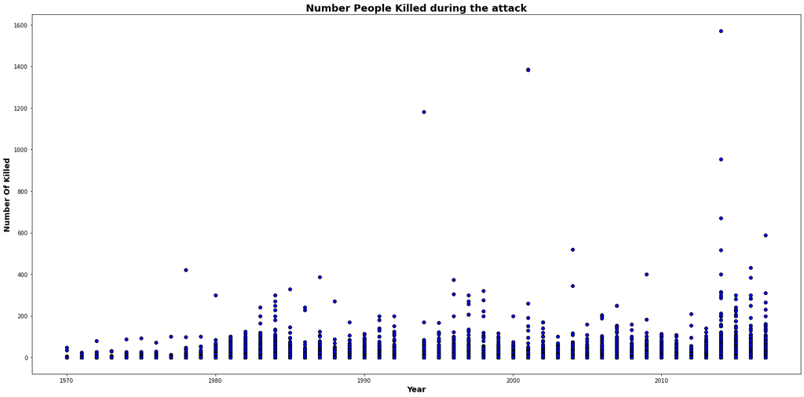

```python
plt.figure(figsize=(25,12))
plt.scatter(data['Year'], data['Killed'], color='b',edgecolor='k')
plt.xlabel('Year',fontweight='bold',fontsize=14)
plt.ylabel('Number Of Killed',fontweight='bold',fontsize=14)
plt.title('Number People Killed during the attack',fontweight='bold',fontsize=18)
plt.show()
```